# Congress Report

Pooja Shree Ramanathan

May 1st, 2018

## Introduction

##### This is a report on the laws that are being created by the *United States Congress*. It includes what the legislators in Congress, the people we voted for, have been doing with the power we have given them. It ellaborates on certain bills the *US government* passes and where more information on similar bills and laws could be found. This report is divided into three divisions as follows:

1. Legislative Data - Informatioin on congressional laws (bills) that have recently been introduced
2. Specific Legislation - Provides an explanation on a specific bill on a chosen topic of legislation
3. Representative Actions - Information about the actions taken by a specific legislator the represents the place I live

### Section 1: Legislative Data

**10 Most recent bills related to Immigration:**

| Bill ID | Name | Legislator Info | Latest action date | Status | More Info |
| --- | --- | --- | --- | --- | --- |
| H.R.5648 | To amend title 28, United States Code, to provide for Supreme Court original jurisdiction over certain immigration actions, and for other purposes. | Louie Gohmert, R, TX | 2018-04-27 | Referred to the House Committee on the Judiciary. | https://www.govtrack.us/congress/bills/115/hr5648 |
| H.R.5653 | To amend the Immigration and Nationality Act to provide that any alien who has been convicted of a felony or two misdemeanors, is deportable, and for other purposes. | Paul Gosar, R, AZ | 2018-04-27 | Referred to the House Committee on the Judiciary. | https://www.govtrack.us/congress/bills/115/hr5653 |
| H.R.5668 | For the relief of Mykhaylo Gnatyuk and Melnik Gnatyuk. | Danny K. Davis, D, IL | 2018-04-27 | Referred to the House Committee on the Judiciary. | https://www.govtrack.us/congress/bills/115/hr5668 |
| H.R.5647 | To include Hungary in the list of foreign states whose nationals are eligible for admission into the United States as E1 and E2 nonimmigrants if United States nationals are treated similarly by the Go… | Steve King, R, IA | 2018-04-27 | Referred to the House Committee on the Judiciary. | https://www.govtrack.us/congress/bills/115/hr5647 |
| H.R.5626 | To amend the Intercountry Adoption Act of 2000 to require the Secretary of State to report on intercountry adoptions from countries which have significantly reduced adoption rates involving immigratio… | Doug Collins, R, GA | 2018-04-26 | Referred to the House Committee on Foreign Affairs. | https://www.govtrack.us/congress/bills/115/hr5626 |
| H.R.5617 | To prohibit sanctuary jurisdictions from receiving Federal funds under the State Criminal Alien Assistance Program, and for other purposes. | Daniel M. Donovan, R, NY | 2018-04-25 | Referred to the House Committee on the Judiciary. | https://www.govtrack.us/congress/bills/115/hr5617 |
| H.R.5619 | To provide emergency funding for port of entry personnel and infrastructure, and for other purposes. | Beto O’Rourke, D, TX | 2018-04-25 | Referred to the Committee on Homeland Security, and in addition to the Committees on Ways and Means, and Appropriations, for a period to be subsequently determined by the Speaker, in each case for con… | https://www.govtrack.us/congress/bills/115/hr5619 |
| H.R.5623 | For the relief of Carmela Apolonio Hernandez, Edwin Artillero Apolonio, Yoselin Artillero Apolonio, Keyri Artillero Apolonio, and Fidel Artillero Apolonio. | Robert A. Brady, D, PA | 2018-04-25 | Referred to the House Committee on the Judiciary. | https://www.govtrack.us/congress/bills/115/hr5623 |
| H.R.5593 | To render certain military spouses eligible for adjustment of status. | Darren Soto, D, FL | 2018-04-24 | Referred to the House Committee on the Judiciary. | https://www.govtrack.us/congress/bills/115/hr5593 |
| H.R.5574 | To prohibit the use of funds appropriated or otherwise available to Department of Homeland Security frontline operational components for the procurement of certain items that do not meet specified cri… | Scott Taylor, R, VA | 2018-04-27 | Referred to the Subcommittee on Oversight and Management Efficiency. | https://www.govtrack.us/congress/bills/115/hr5574 |

1. **Bill ID :** This column is a unique identifier for each of the bills. The bills begin as H.R. and a number depending on the order in which they were introduced.
2. **Name :** This column is the name of the bill.
3. **Legislator Info :** This column consists of information regarding which political representative is involved with the bill. The legislator’s state and party tells you which state and party they represent. The letter R or D after the name represents which party they represent, the Republican’s or Democrats. The two letters after reprents the state they are representing.
4. **Latest Action Date :** This column tells us the date when this bill was last modified.
5. **Status :** This column consists the bill’s current status in the legislative branch. It explains both the House’s and the Senate’s reactions to it, and how far it is from being passed. This column also includes the IDs of any texts of measures
6. **More Info :** This column includes the links to where the full script of the bill can be accessed, as well as additional information about it. The links take you to a government tracking website, updating constituents on the bills their representatives are interacting with.

### Section 2: Specific Legislation

| number | title | introduced_date | legislation_info | latest_major_action_date | latest_major_action | govtrack_url |
| --- | --- | --- | --- | --- | --- | --- |
| H.R.4744 | To impose additional sanctions with respect to serious human rights abuses of the Government of Iran, and for other purposes. | 2018-01-09 | Michael McCaul, R, TX | 2018-04-26 | Motion to reconsider laid on the table Agreed to without objection. | https://www.govtrack.us/congress/bills/115/hr4744 |

1. **number :** This column is a unique identifier for each of the bills. The bills begin as H.R. and a number depending on the order in which they were introduced.
2. **title :** This column is the name of the bill.
3. **Introduced date :** The date this bill was initiated.
4. **Legislator Info :** This column consists of information regarding which political representative is involved with the bill. The legislator’s state and party tells you which state and party they represent. The letter R or D after the name represents which party they represent, the Republican’s or Democrats. The two letters after reprents the state they are representing.
5. **Latest Action Date :** This column tells us the date when this bill was last modified.
6. **Latest Major Action :** This column consists the bill’s current status in the legislative branch. It explains both the House’s and the Senate’s reactions to it, and how far it is from being passed. This column also includes the IDs of any texts of measures
7. **govtrack url :** This column includes the links to where the full script of the bill can be accessed, as well as additional information about it. The links take you to a government tracking website, updating constituents on the bills their representatives are interacting with.

The purpose of this bill is to control serious human rights abuses of the Government of Iran. The Iranian regime persecutes ethnic and religious minority groups, such as the Baha’is, Christians, Sufi, Sunni, and dissenting Shi’a Muslims (such as imprisoned Ayatollah Hossein Kazemeyni Boroujerdi), through harassment, arrests, and imprisonment, during which detainees have routinely been beaten, tortured, and killed. Iran has violated the International Covenant on Civil and Political Rights, and other human right traties and international obligations.

This bill senses that Congress of the United States should deny the Government of Iran the ability to continue to oppress the people of Iran and to use violence and executions to silence pro-democracy protestors. Work with other countries to investigate the human rights violations committed by the Iran officials. It also requires the Unites States to support the people of Iran to establish basic freedom and build foundations for a freely elected, non-corrupt,and open democratic political system.

To achieve the above goals it requires the president to determine whether senior Iranian officials are responsible for human rights abuses and whether official Iranian businesses should be sanctioned for public corruption under existing law. It also imposes blocking of property and denial of visa sanctions to the United States for Iranian Officials and family members responsible for politically motivated detentions of U.S. citizens and residents, or abuses against Iranian expatriates.

##### This bill should be encouraged to voted for and passed into law because the Iranian regime continues to perpetuate so many innocent lives. They suppress the country’s voice by censoring the media and continue their illegal and corrupt practices. In terms of American interest, they have 5 Americans currently held hostages. By enacting this bill, this unhuman and cruel regime will be put to an end by the United States and other countries.

##### Results of this bill:

##### The bill was referred to the Committee on Foreign Affairs, and in addition to the Committees on the Judiciary, Financial Services, and Ways and Means, for a period to be subsequently determined by the Speaker, in each case for consideration of such provisions as fall within the jurisdiction of the committee concerned. This bill was successfully passed with 410 yes, 2 no and 16 no votes on 26th April, 2018.

### Section 3: Representative Actions

#### Name: `Adam Smith`

#### Party: `D`

#### Twitter Info: `RepAdamSmith`

#### Facebook Info: `RepAdamSmith`

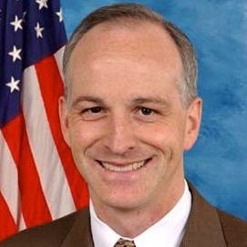

Legislator : Adam Smith : Democratic Party

| number | title | latest_major_action | govtrack_url |
| --- | --- | --- | --- |
| H.R.5233 | To provide for automatic acquisition of United States citizenship for certain internationally adopted individuals, and for other purposes. | Referred to the House Committee on the Judiciary. | https://www.govtrack.us/congress/bills/115/hr5233 |
| H.R.4415 | To establish the policy of the United States regarding the no-first-use of nuclear weapons. | Referred to the House Committee on Foreign Affairs. | https://www.govtrack.us/congress/bills/115/hr4415 |
| H.R.4087 | To direct the Administrator of the Federal Aviation Administration to conduct a study relating to ultrafine particles, and for other purposes. | Referred to the Subcommittee on Aviation. | https://www.govtrack.us/congress/bills/115/hr4087 |
| H.R.3923 | To provide standards for facilities at which aliens in the custody of the Department of Homeland Security are detained, and for other purposes. | Referred to the Subcommittee on Immigration and Border Security. | https://www.govtrack.us/congress/bills/115/hr3923 |
| H.R.3769 | To establish the National Freight Mobility Infrastructure Fund, and for other purposes. | Referred to the Subcommittee on Water Resources and Environment. | https://www.govtrack.us/congress/bills/115/hr3769 |
| H.R.3624 | To authorize voluntary grazing permit retirement on Federal lands managed by the Department of Agriculture or the Department of the Interior where livestock grazing is impractical, and for other purpo… | Referred to the Subcommittee on Conservation and Forestry. | https://www.govtrack.us/congress/bills/115/hr3624 |
| H.R.3025 | To strengthen security and deterrence in Europe and to hold the Russian Federation accountable for violations of the Intermediate-Range Nuclear Forces Treaty, and for other purposes. | Referred to the Committee on Foreign Affairs, and in addition to the Committee on Armed Services, for a period to be subsequently determined by the Speaker, in each case for consideration of such prov… | https://www.govtrack.us/congress/bills/115/hr3025 |
| H.R.1745 | To amend the Balanced Budget and Emergency Deficit Control Act of 1985 to eliminate the section 251A sequestrations. | Referred to the House Committee on the Budget. | https://www.govtrack.us/congress/bills/115/hr1745 |
| H.R.753 | To establish a fair and transparent process that will result in the timely consolidation, closure, and realignment of military installations inside the United States and will realize improved efficien… | Referred to the Subcommittee on Readiness. | https://www.govtrack.us/congress/bills/115/hr753 |
| H.R.6284 | To amend the Federal Food, Drug, and Cosmetic Act to prohibit the marketing of authorized generic drugs. | Referred to the House Committee on Energy and Commerce. | https://www.govtrack.us/congress/bills/114/hr6284 |
| H.R.6193 | To establish the National Freight Mobility Infrastructure Fund, and for other purposes. | Referred to House Ways and Means | https://www.govtrack.us/congress/bills/114/hr6193 |
| H.R.5540 | To establish a fair and transparent process that will result in the timely consolidation, closure, and realignment of military installations inside the United States and will realize improved efficien… | Referred to the Subcommittee on Readiness. | https://www.govtrack.us/congress/bills/114/hr5540 |
| H.R.5454 | To provide for automatic acquisition of United States citizenship for certain internationally adopted individuals, and for other purposes. | Referred to the Subcommittee on Immigration and Border Security. | https://www.govtrack.us/congress/bills/114/hr5454 |
| H.R.4728 | To amend title II of the Social Security Act to expand the exception to the windfall elimination provision based on years of coverage. | Referred to the Subcommittee on Social Security. | https://www.govtrack.us/congress/bills/114/hr4728 |
| H.R.4512 | To amend the Balanced Budget and Emergency Deficit Control Act of 1985 to eliminate the section 251A sequestrations. | Referred to the House Committee on the Budget. | https://www.govtrack.us/congress/bills/114/hr4512 |
| H.R.3410 | To authorize voluntary grazing permit retirement on Federal lands managed by the Department of Agriculture or the Department of the Interior where livestock grazing is impractical, and for other purpo… | Referred to the Subcommittee on Federal Lands. | https://www.govtrack.us/congress/bills/114/hr3410 |
| H.R.2314 | To ensure the humane treatment of persons detained pursuant to the Immigration and Nationality Act. | Referred to the Subcommittee on Immigration and Border Security. | https://www.govtrack.us/congress/bills/114/hr2314 |
| H.R.1088 | To extend the trade adjustment assistance program, and for other purposes. | Referred to the Subcommittee on Health, Employment, Labor, and Pensions. | https://www.govtrack.us/congress/bills/114/hr1088 |
| H.R.1012 | To amend title XVIII of the Social Security Act to improve the provision of items and services provided to Medicare beneficiaries residing in rural areas, and for other purposes. | Referred to the Subcommittee on Health. | https://www.govtrack.us/congress/bills/114/hr1012 |
| H.R.955 | To authorize assistance and sustainment to the military and national security forces of Ukraine. | Referred to House Armed Services | https://www.govtrack.us/congress/bills/114/hr955 |

1. **number :** This column is a unique identifier for each of the bills. The bills begin as H.R. and a number depending on the order in which they were introduced.
2. **title :** This column is the name of the bill.
3. **Last Major Action :** This column consists the bill’s current status in the legislative branch. It explains both the House’s and the Senate’s reactions to it, and how far it is from being passed. This column also includes the IDs of any texts of measures
4. **govtrack url :** This column includes the links to where the full script of the bill can be accessed, as well as additional information about it. The links take you to a government tracking website, updating constituents on the bills their representatives are interacting with.

### `Adam Smith` is a Democratic party representative, but he has taken a position where he represented the majority of the opposing party (Republicans) `35` % of the time.